# Final Project

Michael Cheng and Ben Dreier

5/13/2019

## Intro

This Rmd file will present a few highlights of the full analysis present in the Final.R file.

First, let’s load the data file. Let M be the data file.

```
##                Name Address.Number         Street.Name          City
## 1 Beatrice Frianson            824 North Hitlien Drive Beverly Hills
## 2       Lauson Ford           1215    East 49th Street   Los Angeles
## 3      Bessie Evans           1203    East 41st Street   Los Angeles
## 4   Lillian Summers           4224       Hooper Avenue   Los Angeles
## 5        Cleo Chase           1127     East 43rd Place   Los Angeles
## 6      Arthur Rolfe            705     East 43rd Place   Los Angeles
##               Former.Church        Hometown Distance State.Population
## 1 Saint John Baptist Church    Houston, TX   2491141          6414824
## 2    Mission Baptist Church     Mississippi  3037873          2183796
## 3          Phillips Temple  Los Angeles, CA        0          6907387
## 4         Bethel AME Church San Antonio, TX  2176784          6414824
## 5       Metropolitan Church San Antonio, TX  2176784          6414824
## 6                   Convert Los Angeles, CA        0          6907387
##         State
## 1       Texas
## 2 Mississippi
## 3  California
## 4       Texas
## 5       Texas
## 6  California
```

## SECTION 1: Hometown analysis with Contingency Table

Is having a hometown that isn’t Los Angeles correlated with being a Convert from another/no religion? My hypothesis: In theory, it could make sense because people who moved from further away towns might have joined the church in search of community, then converted religions While people originally from LA already had a community from growing up there; or another factor could dominate

First, let’s find out the number of people from LA and the number of converts

```r
HomeLA <- which(M$Hometown == "Los Angeles, CA") #People with hometowns LA
length(HomeLA) #Los Angeles, CA has 1,232
```

```
## [1] 1232
```

```r
HomeNotLA <- which(M$Hometown != "Los Angeles, CA") #All people who were not from LA
length(HomeNotLA) #Not LA has 1,814
```

```
## [1] 1814
```

```r
ConvertsA <-which(M$Former.Church == "Convert") #All the converts
length(ConvertsA) #427 converts
```

```
## [1] 427
```

```r
NotConverts <-which(M$Former.Church != "Convert") #All the non-converts
length(NotConverts) #2,619 non-converts
```

```
## [1] 2619
```

```r
# And put it in a data fram
LA <- M$Hometown == "Los Angeles, CA"
Converts <- M$Former.Church == "Convert"
HomeR <- data.frame(LA, Converts) #make a dataframe with just the logical columns
```

We can run a chi squared test to see how dependent the variables of Being from LA and Being a Convert are:

```r
chisq.test(HomeR$LA,HomeR$Converts)
```

```
##
##  Pearson's Chi-squared test with Yates' continuity correction
##
## data:  HomeR$LA and HomeR$Converts
## X-squared = 711.23, df = 1, p-value < 2.2e-16
```

The p value is very small, so it is incredibly unlikely that the correlation between LA and Converts arose by chance. We can take this as evidence enough that there is a strong correlation between being from LA and being a Convert

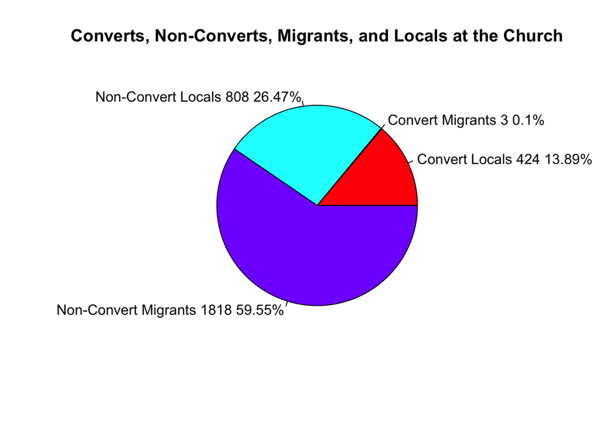

## SECTION 3: Comparing Baptism with Distance Travelled using Permutation Test

Looking at the dataset, we see a lot of Baptist representation. Now, we want to figure out whether being a Baptist is correlated at all with Distance Traveled using a Permutation test.

The following code uses a word-search algorithm to guess which churches in the dataset are Baptist churches.

```r
Churches <- (M$Former.Church) #column of all individuals churches
Denoms <- c("Baptist", "Methodist", "AME", "Episcopal", "CME", "Presbyterian", "Catholic") # Enumerate some words pointing to church denomination
# Function to get which churches contain which denomination strings
whichContain <- function(ch, dn){
  denoms <- rep("", length(ch))
  i <- 1
  for(c in ch){
    for(d in dn){
      #Check if the church has the denomination
      if( is.na(grepl(d, c)) ){break}
      if( grepl(d, c) ){
        denoms[i] = paste(denoms[i], d);
      }
    }
    i <- i + 1
  }
  return(denoms)
}
WhichDenoms <- whichContain(Churches, Denoms)
isBaptist <- WhichDenoms == " Baptist";  #true if an individual is Baptist

sum(isBaptist)
```

```
## [1] 1185
```

We found 1185 Baptist churches. Out of only 3,046 individuals, this represents a big part of the population.

Now, calculate the observed differences between Distance Travelled for Baptists vs Non-Baptists

```r
km <- M$Distance / 1000 #divide distance by 1000 to get distance in km
mean(km) #mean distance for all Individuals is 1580.57 km
```

```
## [1] 1580.572
```

```r
median(km) #median distance for all Individuals is 2137 km
```

```
## [1] 2137
```

```r
#Calculate the observed Distance Traveled for Baptists and non-Baptists
dBaptists <- sum((km) * (isBaptist == TRUE))/sum(isBaptist == TRUE) #average distance for Baptists is 2028.802 km
dOthers <- sum((km) * (isBaptist == FALSE))/sum(isBaptist == FALSE) #average distance for non-Baptists is 1295.159 km
observed <- dBaptists - dOthers; observed #on average, Baptists traveled 733.64 km farther than non-Baptists
```

```
## [1] 733.6425
```

Now we can perform a permutation test to determine if this difference could have arisen by chance.

```r
N <- 10000
diffs <- numeric(N)
for(i in 1:N){
  Samp <- sample(isBaptist); Samp #permuted isBaptist column
  dBaptists <- sum((km) * (Samp == TRUE))/sum(Samp == TRUE); dBaptists
  dOthers <- sum((km) * (Samp == FALSE))/sum(Samp == FALSE)
  diffs[i] = dBaptists - dOthers #as likely to be negative or positive
}

# The mean should hover near zero
mean(diffs)
```

```
## [1] 0.3486066
```

We can plot a histogram of observed differences from the permutation test to visually confirm that the differences are normally distributed with a mean of 0

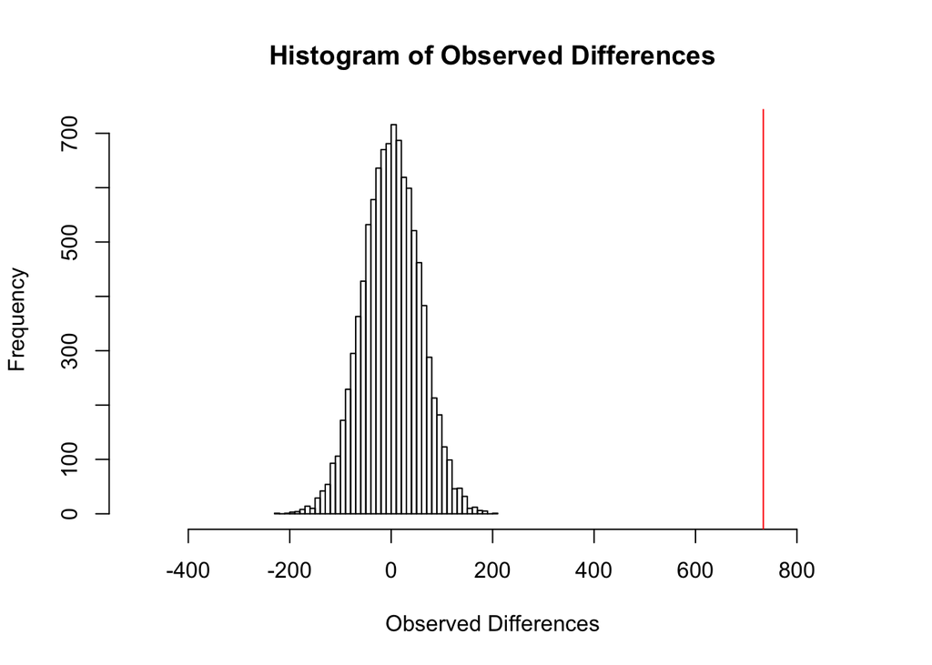

The red line, at the observed difference in the non-permuted data, is a statistical outlier. We can get its p-value:

```r
pvalue <- (sum(diffs >= observed)+1)/(N+1); pvalue
```

```
## [1] 9.999e-05
```

And see that there was about a 0.0001 chance of this difference occuring by chance.

We can conclude that, for whatever reason, Baptists at the People’s Independent Church migrated from further distances than non-Baptists, on average 733.64 km further.

## SECTION 6: Mapping the Hometown data

For visual analysis and presentation, we can create a map using the hometown addresses in the data set. Location data was generated in R using the Google Maps API, but now we load data from a saved backup instead of fetching it all again. We also have access to a json file defining where and how to plot state outlines.

```r
locs_file <- read.csv("locations2.csv")
states <- geojsonio::geojson_read("us-states.json", what="sp")
```

Now we count the number of times each state enumerated in the states object occurs in the dataset; this is what we will plot on our heatmap.

```r
counts = {}
for(i in 1:length(states$name)){
  curr_state <- toString(states$name[i])
  state_count <- length(M$State[M$State == curr_state])
  counts = c(counts, state_count)
}

# Put these counts in the states object used for visualization
states$count <- counts
```

After deciding how to delineate color bins and creating a palette, we can use leaflet to map how frequently each state appears.

[interactive chart not shown]

Then, using the individual location data gathered earlier, we plot every member on the map.

[interactive chart not shown]

Darker dots represent multiple individuals who live in the same town.